# Modeling

## Modeling Total Shootings for each State using Regression

### Data Preprocessing

We start by merging the datasets and scaling the numeric variables for better interpretability in modeling.

```r
library(dplyr)
library(tidyr)
library(MASS)
library(modelr)
library(ggplot2)

# Load and clean mass shootings data
mass_shootings <- read.csv("data/mass_shootings_2018_2024_cleaned.csv") |>
  mutate(State = case_when(
    State == "Washington, D.C." ~ "District of Columbia",
    TRUE ~ State
  ))

# Load and clean census data
census_data <- read.csv("state_data.csv") |>
  rename(State = NAME) |>
  mutate(across(where(is.numeric), ~ as.numeric(scale(.))))

# Merge datasets by State
scaled_data <- mass_shootings |>
  group_by(State) |>
  summarise(total_shootings = n(),
            total_deaths = sum(Dead, na.rm = TRUE),
            total_injuries = sum(Injured, na.rm = TRUE)) |>
  left_join(census_data, by = "State")
```

### Correlation Analysis

Before modeling, we explore the relationships between shooting frequencies and socio-economic variables. First we have to remove NAs before doing correlation analysis.

```r
scaled_data <- scaled_data %>%
  drop_na(total_shootings, total_populationE, median_incomeE,
          unemployment_rate, poverty_rate, bachelors_and_higher)
```

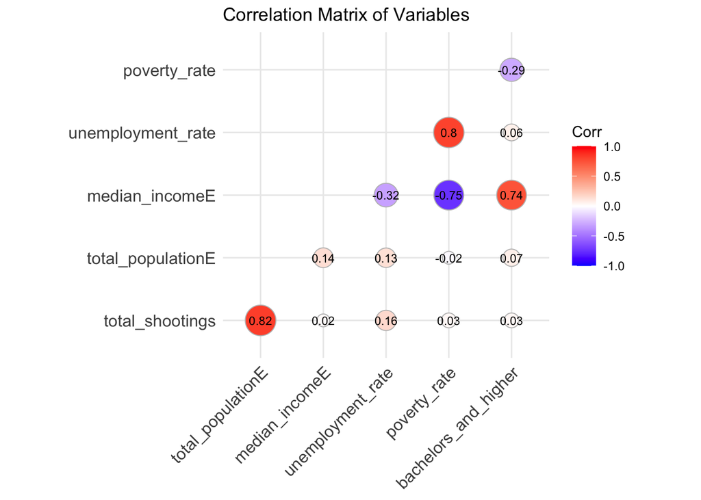

```r
library(ggcorrplot)

# Compute correlation matrix for scaled data
cor_matrix <- scaled_data %>%
  dplyr::select(total_shootings, total_populationE, median_incomeE, unemployment_rate,
                poverty_rate, bachelors_and_higher) %>%
  cor()

# Visualize correlation matrix
ggcorrplot(cor_matrix,
           method = "circle",
           type = "lower",
           lab = TRUE,
           lab_size = 3,
           title = "Correlation Matrix of Variables",
           colors = c("blue", "white", "red"))
```

The correlation matrix highlights strong positive relationships, particularly between total_shootings and total_populationE (r=0.82), indicating that states with larger populations experience more shootings. Other variables, such as poverty_rate and bachelors_and_higher, show weaker correlations with shootings, suggesting less direct influence.

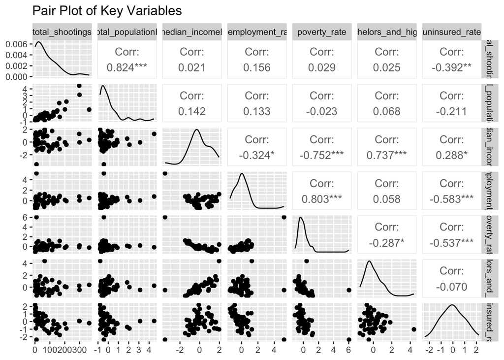

```r
library(GGally)

# Select relevant variables for pair plot
pair_data <- scaled_data |>
  dplyr::select(total_shootings, total_populationE, median_incomeE,
         unemployment_rate, poverty_rate, bachelors_and_higher, uninsured_rate)

# Plot pairwise relationships
ggpairs(pair_data,
        title = "Pair Plot of Key Variables")
```

The pair plot shows total_shootings is positively correlated with total_populationE and is right-skewed, indicating a few high-shooting states. Scatterplots confirm strong relationships with population, while other variables like poverty_rate show weaker trends. This supports further investigation into population as a key factor.

### Poisson Regression

Poisson regression is used for modeling count data, like the total number of shootings per state.

```r
# Poisson regression model
poisson_model <- glm(total_shootings ~ total_populationE + median_incomeE +
                       unemployment_rate + poverty_rate + bachelors_and_higher +
                       uninsured_rate + vacancy_rate,
                     family = poisson(link = "log"),
                     data = scaled_data)
summary(poisson_model)
```

```
##
## Call:
## glm(formula = total_shootings ~ total_populationE + median_incomeE +
##     unemployment_rate + poverty_rate + bachelors_and_higher +
##     uninsured_rate + vacancy_rate, family = poisson(link = "log"),
##     data = scaled_data)
##
## Coefficients:
##                      Estimate Std. Error z value Pr(>|z|)
## (Intercept)           3.78983    0.02645 143.302  < 2e-16 ***
## total_populationE     0.52032    0.01385  37.565  < 2e-16 ***
## median_incomeE       -1.18236    0.06457 -18.310  < 2e-16 ***
## unemployment_rate     0.49933    0.05295   9.429  < 2e-16 ***
## poverty_rate         -1.13064    0.07441 -15.196  < 2e-16 ***
## bachelors_and_higher  0.29858    0.04118   7.251 4.12e-13 ***
## uninsured_rate       -0.70306    0.02843 -24.726  < 2e-16 ***
## vacancy_rate         -0.60066    0.03384 -17.748  < 2e-16 ***
## ---
## Signif. codes:  0 '***' 0.001 '**' 0.01 '*' 0.05 '.' 0.1 ' ' 1
##
## (Dispersion parameter for poisson family taken to be 1)
##
##     Null deviance: 4124.31  on 50  degrees of freedom
## Residual deviance:  820.49  on 43  degrees of freedom
## AIC: 1111.5
##
## Number of Fisher Scoring iterations: 5
```

The Poisson regression model provides a good initial framework to analyze count data, like the total number of shootings. The coefficients indicate the log-relative rate of shootings for each predictor. For instance:

- total_populationE has a positive coefficient, meaning states with larger populations are associated with higher shooting rates.
- median_incomeE have significant negative coefficients, suggesting states with higher income levels experience fewer shootings.
- The residual deviance (820.49) is much smaller than the null deviance (4124.31), indicating the model explains a substantial portion of the variability.

**Dispersion Test:** To determine if overdispersion exists (dispersion parameter >> 1), calculate the dispersion ratio:

```r
dispersion_ratio <- summary(poisson_model)$deviance / summary(poisson_model)$df.residual
dispersion_ratio
```

```
## [1] 19.08125
```

Since the dispersion ratio is significantly greater than 1, it indicates overdispersion, and a Negative Binomial regression model should be used.

### Negative Binomial Regression for Overdispersion

```r
# Negative binomial regression model
negbin_model <- glm.nb(total_shootings ~ total_populationE + median_incomeE +
                         unemployment_rate + poverty_rate + bachelors_and_higher +
                         uninsured_rate + vacancy_rate,
                       data = scaled_data)
summary(negbin_model)
```

```
##
## Call:
## glm.nb(formula = total_shootings ~ total_populationE + median_incomeE +
##     unemployment_rate + poverty_rate + bachelors_and_higher +
##     uninsured_rate + vacancy_rate, data = scaled_data, init.theta = 3.254641924,
##     link = log)
##
## Coefficients:
##                      Estimate Std. Error z value Pr(>|z|)
## (Intercept)           3.69770    0.08510  43.450  < 2e-16 ***
## total_populationE     0.60325    0.09043   6.671 2.55e-11 ***
## median_incomeE       -1.08947    0.29819  -3.654 0.000259 ***
## unemployment_rate     0.44184    0.21927   2.015 0.043904 *
## poverty_rate         -1.13688    0.32949  -3.450 0.000560 ***
## bachelors_and_higher  0.28170    0.17230   1.635 0.102057
## uninsured_rate       -0.88116    0.11467  -7.684 1.54e-14 ***
## vacancy_rate         -0.65904    0.12637  -5.215 1.84e-07 ***
## ---
## Signif. codes:  0 '***' 0.001 '**' 0.01 '*' 0.05 '.' 0.1 ' ' 1
##
## (Dispersion parameter for Negative Binomial(3.2546) family taken to be 1)
##
##     Null deviance: 234.887  on 50  degrees of freedom
## Residual deviance:  53.801  on 43  degrees of freedom
## AIC: 480.16
##
## Number of Fisher Scoring iterations: 1
##
##
##               Theta:  3.255
##           Std. Err.:  0.721
##
##  2 x log-likelihood:  -462.161
```

$$\text{Relative Rate Change} = e^{-1.13688} \approx 0.32$$

My first suspicion was multicollinearity. Since poverty rate often correlates with other socio-economic factors, such as `median_incomeE` and `unemployment_rate`, it’s possible that the model distributes the explanatory power across these variables.

To test this, let’s calculated the Variance Inflation Factor (VIF):

```r
library(car)
vif(negbin_model)
```

```
##    total_populationE       median_incomeE    unemployment_rate
##             1.258566            13.107502             6.427476
##         poverty_rate bachelors_and_higher       uninsured_rate
##            15.167083             4.327835             1.678355
##         vacancy_rate
##             1.915198
```

The VIF results reveal multicollinearity, particularly for median_incomeE (VIF = 13.11) and poverty_rate (VIF = 15.17), suggesting their effects overlap with each other and unemployment_rate (VIF = 6.43). This multicollinearity may distort the coefficients, especially for poverty_rate, which shows a counterintuitive negative relationship.

### Steps to Address Multicollinearity

#### Test Reduced Models:

- Exclude `poverty_rate`:

```r
model_no_poverty <- glm.nb(total_shootings ~ total_populationE + median_incomeE +
                            unemployment_rate + bachelors_and_higher +
                            uninsured_rate + vacancy_rate,
                          data = scaled_data)

summary(model_no_poverty)
```

```
##
## Call:
## glm.nb(formula = total_shootings ~ total_populationE + median_incomeE +
##     unemployment_rate + bachelors_and_higher + uninsured_rate +
##     vacancy_rate, data = scaled_data, init.theta = 2.673428227,
##     link = log)
##
## Coefficients:
##                       Estimate Std. Error z value Pr(>|z|)
## (Intercept)           3.721678   0.092403  40.277  < 2e-16 ***
## total_populationE     0.646115   0.099526   6.492 8.48e-11 ***
## median_incomeE       -0.259945   0.192885  -1.348    0.178
## unemployment_rate    -0.093382   0.125529  -0.744    0.457
## bachelors_and_higher -0.006344   0.168355  -0.038    0.970
## uninsured_rate       -0.839009   0.123867  -6.773 1.26e-11 ***
## vacancy_rate         -0.669868   0.138744  -4.828 1.38e-06 ***
## ---
## Signif. codes:  0 '***' 0.001 '**' 0.01 '*' 0.05 '.' 0.1 ' ' 1
##
## (Dispersion parameter for Negative Binomial(2.6734) family taken to be 1)
##
##     Null deviance: 196.729  on 50  degrees of freedom
## Residual deviance:  54.162  on 44  degrees of freedom
## AIC: 487.56
##
## Number of Fisher Scoring iterations: 1
##
##
##               Theta:  2.673
##           Std. Err.:  0.572
##
##  2 x log-likelihood:  -471.565
```

Check the VIF of model_no_poverty

```r
vif(model_no_poverty)
```

```
##    total_populationE       median_incomeE    unemployment_rate
##             1.267787             4.716443             1.902787
## bachelors_and_higher       uninsured_rate         vacancy_rate
##             3.459854             1.723762             1.944305
```

There is still a multicollinearity, let’s exclude `bachelors_and_higher`

```r
model_no_poverty_educate <- glm.nb(total_shootings ~ total_populationE + median_incomeE +
                            unemployment_rate +
                            uninsured_rate + vacancy_rate,
                          data = scaled_data)
summary(model_no_poverty_educate)
```

```
##
## Call:
## glm.nb(formula = total_shootings ~ total_populationE + median_incomeE +
##     unemployment_rate + uninsured_rate + vacancy_rate, data = scaled_data,
##     init.theta = 2.674675624, link = log)
##
## Coefficients:
##                   Estimate Std. Error z value Pr(>|z|)
## (Intercept)        3.72178    0.09229  40.325  < 2e-16 ***
## total_populationE  0.64693    0.09647   6.706 2.00e-11 ***
## median_incomeE    -0.26685    0.11716  -2.278   0.0227 *
## unemployment_rate -0.09405    0.11557  -0.814   0.4158
## uninsured_rate    -0.83706    0.11998  -6.976 3.03e-12 ***
## vacancy_rate      -0.66976    0.13873  -4.828 1.38e-06 ***
## ---
## Signif. codes:  0 '***' 0.001 '**' 0.01 '*' 0.05 '.' 0.1 ' ' 1
##
## (Dispersion parameter for Negative Binomial(2.6747) family taken to be 1)
##
##     Null deviance: 196.813  on 50  degrees of freedom
## Residual deviance:  54.185  on 45  degrees of freedom
## AIC: 485.57
##
## Number of Fisher Scoring iterations: 1
##
##
##               Theta:  2.675
##           Std. Err.:  0.573
##
##  2 x log-likelihood:  -471.566
```

Check the VIF of model_no_poverty_educate

```r
vif(model_no_poverty_educate)
```

```
## total_populationE    median_incomeE unemployment_rate    uninsured_rate
##          1.191642          1.740896          1.614003          1.618068
##      vacancy_rate
##          1.944939
```

All VIF values are below 2, indicating that multicollinearity is no longer a concern in the model.

Removing `poverty_rate` and `bachelors_and_higher` resolved the previous collinearity issues, allowing for a more interpretable model.

### Model Selection

#### Stepwise Selection

```r
stepwise_model <- stepAIC(model_no_poverty_educate, direction = "both")
```

```
## Start:  AIC=483.57
## total_shootings ~ total_populationE + median_incomeE + unemployment_rate +
##     uninsured_rate + vacancy_rate
##
##                     Df    AIC
## - unemployment_rate  1 482.00
## <none>                 483.57
## - median_incomeE     1 485.65
## - vacancy_rate       1 499.22
## - total_populationE  1 513.17
## - uninsured_rate     1 514.85
##
## Step:  AIC=482
## total_shootings ~ total_populationE + median_incomeE + uninsured_rate +
##     vacancy_rate
##
##                     Df    AIC
## <none>                 482.00
## + unemployment_rate  1 483.57
## - median_incomeE     1 484.21
## - vacancy_rate       1 497.98
## - total_populationE  1 511.22
## - uninsured_rate     1 517.53
```

```r
summary(stepwise_model)
```

```
##
## Call:
## glm.nb(formula = total_shootings ~ total_populationE + median_incomeE +
##     uninsured_rate + vacancy_rate, data = scaled_data, init.theta = 2.626343491,
##     link = log)
##
## Coefficients:
##                   Estimate Std. Error z value Pr(>|z|)
## (Intercept)        3.72304    0.09308  40.000  < 2e-16 ***
## total_populationE  0.64452    0.09676   6.661 2.72e-11 ***
## median_incomeE    -0.27433    0.11718  -2.341   0.0192 *
## uninsured_rate    -0.80093    0.10590  -7.563 3.94e-14 ***
## vacancy_rate      -0.67625    0.13869  -4.876 1.08e-06 ***
## ---
## Signif. codes:  0 '***' 0.001 '**' 0.01 '*' 0.05 '.' 0.1 ' ' 1
##
## (Dispersion parameter for Negative Binomial(2.6263) family taken to be 1)
##
##     Null deviance: 193.58  on 50  degrees of freedom
## Residual deviance:  53.77  on 46  degrees of freedom
## AIC: 484
##
## Number of Fisher Scoring iterations: 1
##
##
##               Theta:  2.626
##           Std. Err.:  0.557
##
##  2 x log-likelihood:  -472.004
```

#### Nested Model Hypothesis Testing

**Hypotheses:**

- Null Hypothesis (H₀): The simpler model (without unemployment_rate) is sufficient; adding `unemployment_rate` does not improve model fit significantly.
- Alternative Hypothesis (H₁): The more complex model (with `unemployment_rate`) significantly improves model fit.

```r
nested_model <- glm.nb(total_shootings ~ total_populationE + median_incomeE + uninsured_rate + vacancy_rate,
                       data = scaled_data)
anova(nested_model, model_no_poverty_educate, test = "Chisq")
```

```
## Likelihood ratio tests of Negative Binomial Models
##
## Response: total_shootings
##                                                                                    Model
## 1                     total_populationE + median_incomeE + uninsured_rate + vacancy_rate
## 2 total_populationE + median_incomeE + unemployment_rate + uninsured_rate + vacancy_rate
##      theta Resid. df    2 x log-lik.   Test    df  LR stat.   Pr(Chi)
## 1 2.626343        46       -472.0038
## 2 2.674676        45       -471.5662 1 vs 2     1 0.4376088 0.5082789
```

**Result:**

Since the p-value is 0.5083, We fail to reject the null hypothesis (H₀). This means that adding `unemployment_rate` does not significantly improve the model fit.

### Validation with Bootstrap and Cross-Validation

#### Bootstrap

Create bootstrap samples and fit the Negative Binomial model to each sample:

```r
library(purrr)
set.seed(123)
boot_samples <- bootstrap(scaled_data, 1000)

boot_results <- boot_samples |>
  mutate(model = map(strap, ~ glm.nb(total_shootings ~ total_populationE + median_incomeE +
                                       uninsured_rate + vacancy_rate, data = .x)),
         coefficients = map(model, broom::tidy))  # Extract coefficients
```

Extract and summarize the bootstrap coefficients to calculate mean estimates and confidence intervals:

```r
boot_coefficients <- boot_results |>
  unnest(coefficients) |>
  group_by(term) |>
  summarize(mean_estimate = mean(estimate),
            conf_low = quantile(estimate, 0.025),
            conf_high = quantile(estimate, 0.975))

boot_coefficients
```

```
## # A tibble: 5 × 4
##   term              mean_estimate conf_low conf_high
##   <chr>                     <dbl>    <dbl>     <dbl>
## 1 (Intercept)               3.73     3.50     3.93
## 2 median_incomeE           -0.285   -0.566   -0.0100
## 3 total_populationE         0.701    0.438    1.18
## 4 uninsured_rate           -0.799   -1.03    -0.548
## 5 vacancy_rate             -0.682   -1.03    -0.376
```

The bootstrap results closely align with the original model, confirming stability and robustness. All coefficients fall within their respective confidence intervals, with significant effects maintained for `total_populationE`, `median_incomeE`, `uninsured_rate`, and `vacancy_rate`, supporting the reliability of the model.

#### Monte Carlo Cross-Validation

Use `crossv_mc` to split the data into training and testing sets 100 times. And then apply the Negative Binomial model to the training sets and evaluate performance on the test sets.

```r
set.seed(123)

# Generate 100 Monte Carlo train-test splits
cv_df <- crossv_mc(scaled_data, 100) |>
  mutate(
    train = map(train, as_tibble),
    test = map(test, as_tibble)
  )

# Fit models on training data and calculate RMSE on test data
cv_df <- cv_df |>
  mutate(
    # Model with unemployment_rate
    model_with_unemp = map(train, \(df) glm.nb(total_shootings ~ total_populationE +
                                                median_incomeE +
                                                unemployment_rate +
                                                uninsured_rate +
                                                vacancy_rate,
                                              data = df)),
    # Model without unemployment_rate
    model_without_unemp = map(train, \(df) glm.nb(total_shootings ~ total_populationE +
                                                   median_incomeE +
                                                   uninsured_rate +
                                                   vacancy_rate,
                                                 data = df))
  ) |>
  mutate(
    # Calculate RMSE for models
    rmse_with_unemp = map2_dbl(model_with_unemp, test, \(mod, df) {
      predicted <- predict(mod, newdata = df, type = "response")
      sqrt(mean((df$total_shootings - predicted)^2))
    }),
    rmse_without_unemp = map2_dbl(model_without_unemp, test, \(mod, df) {
      predicted <- predict(mod, newdata = df, type = "response")
      sqrt(mean((df$total_shootings - predicted)^2))
    })
  )
```

Calculate RMSE as a performance metric for each test set.

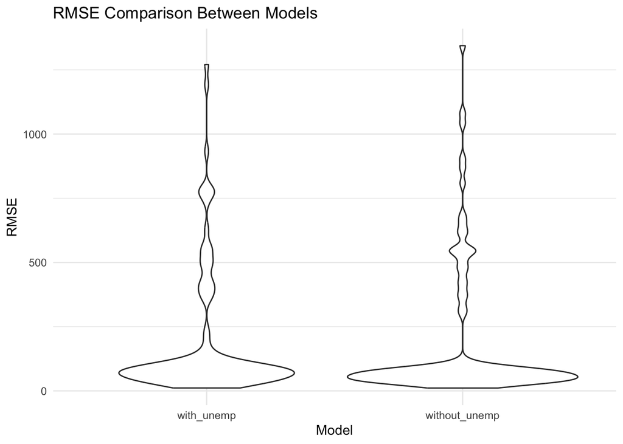

```r
library(forcats)
# Reshape RMSE results for visualization
rmse_comparison <- cv_df |>
  dplyr::select(starts_with("rmse")) |>
  pivot_longer(
    everything(),
    names_to = "model",
    values_to = "rmse",
    names_prefix = "rmse_"
  ) |>
  mutate(model = fct_inorder(model))

# Plot RMSE distributions
ggplot(rmse_comparison, aes(x = model, y = rmse)) +
  geom_violin() +
  labs(
    title = "RMSE Comparison Between Models",
    x = "Model",
    y = "RMSE"
  ) +
  theme_minimal()
```

### Visualize Predictions

Assess how well the model predictions align with the observed data.

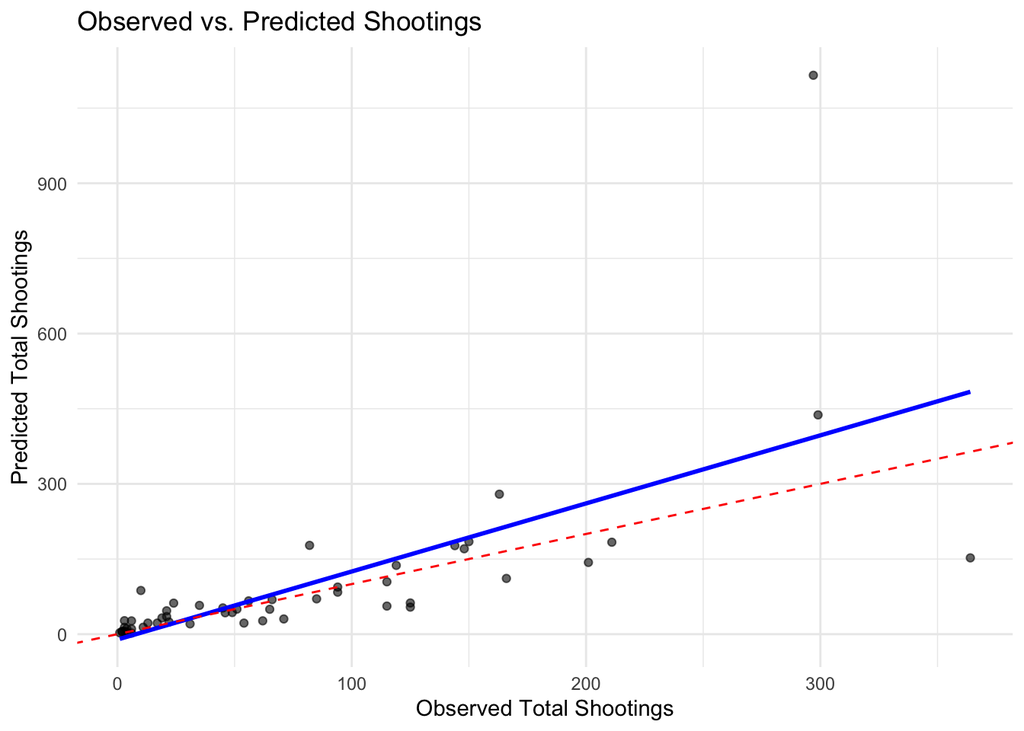

```r
scaled_data <- scaled_data |>
  mutate(predicted_shootings = predict(nested_model, type = "response"))

ggplot(scaled_data, aes(x = total_shootings, y = predicted_shootings)) +
  geom_point(alpha = 0.6) +
  geom_smooth(method = "lm", color = "blue", se = FALSE) +  # Add trend line
  geom_abline(slope = 1, intercept = 0, color = "red", linetype = "dashed") +  # Reference line
  labs(
    title = "Observed vs. Predicted Shootings",
    x = "Observed Total Shootings",
    y = "Predicted Total Shootings"
  ) +
  theme_minimal()
```

Finally, the Negative Binomial regression model is expressed as:

$$\log(\text{E}[\text{Total Shootings}_i]) = 3.72 + 0.64 \cdot
\text{Population}_i - 0.27 \cdot \text{Income}_i - 0.80 \cdot
\text{Uninsured Rate}_i - 0.67 \cdot \text{Vacancy Rate}_i$$

Interpretation of the coefficients:

- Population: a 1-unit increase in scaled population is associated with a 89% increase in expected shootings
- Median Income: a 1-unit increase in scaled median income is associated with a 24% decrease in expected shootings
- Uninsured Rate: a 1-unit increase in scaled uninsured rate is associated with a 56% decrease in expected shootings
- Vacancy Rate: a 1-unit increase in scaled vacancy rate is associated with a 49% decrease in expected shootings

## Classifying Risk Levels of Regions Based on Shooting Data

Now let’s proceed to classify the regions into low-risk (<100), medium-risk (100-200), and high-risk (>200) categories and build a classification model based on this data. Since the dataset is small, we’ll use methods suitable for small datasets, such as Logistic Regression or Decision Trees.

### Data Preparation

```r
# Add risk categories
scaled_data <- scaled_data |>
  mutate(risk_category = case_when(
    total_shootings < 100 ~ "Low",
    total_shootings >= 100 & total_shootings <= 200 ~ "Medium",
    total_shootings > 200 ~ "High"
  ))

# Convert to a factor for modeling
scaled_data$risk_category <- factor(scaled_data$risk_category, levels = c("Low", "Medium", "High"))

# Check the distribution of categories
table(scaled_data$risk_category)
```

```
##
##    Low Medium   High
##     36     10      5
```

### Build a Classification Model

Split the data into training and testing sets:

```r
set.seed(1)
library(caret)
train_index <- createDataPartition(scaled_data$risk_category, p = 0.8, list = FALSE)
train_data <- scaled_data[train_index, ]
test_data <- scaled_data[-train_index, ]
```

Fit a Multinomial Logistic Regression Model

```r
library(nnet)

# Fit the multinomial logistic regression model
multinom_model <- multinom(risk_category ~ total_populationE + median_incomeE +
                             unemployment_rate + uninsured_rate + vacancy_rate,
                           data = train_data)
summary(multinom_model)
```

```
## Call:
## multinom(formula = risk_category ~ total_populationE + median_incomeE +
##     unemployment_rate + uninsured_rate + vacancy_rate, data = train_data)
##
## Coefficients:
##        (Intercept) total_populationE median_incomeE unemployment_rate
## Medium   -38.99441          275.4516       15.91964         -67.61395
## High     -83.98598          340.4495      -50.45712        -108.24227
##        uninsured_rate vacancy_rate
## Medium     -108.07819     64.62532
## High        -46.03537     11.54293
##
## Std. Errors:
##        (Intercept) total_populationE median_incomeE unemployment_rate
## Medium    23253.99          98748.66       18472.03          28480.86
## High      16440.38         100391.35       15418.06          29012.49
##        uninsured_rate vacancy_rate
## Medium       41892.69    15749.963
## High         18035.10     6585.488
##
## Residual Deviance: 0.0008703844
## AIC: 24.00087
```

### Evaluate the Model

#### Use k-fold cross-validation to validate model performance.

```r
library(caret)

# Define cross-validation settings
cv_control <- trainControl(method = "cv", number = 10)

# Train the model with cross-validation
cv_model <- train(
  risk_category ~ total_populationE + median_incomeE +
    unemployment_rate + uninsured_rate + vacancy_rate,
  data = train_data,
  method = "multinom",
  trControl = cv_control
)

# View cross-validation results
print(cv_model)
```

[output not shown]

#### Predict risk categories on the test dataset:

```r
# Predict on the test set
predictions <- predict(multinom_model, newdata = test_data)

# Confusion Matrix
confusionMatrix(predictions, test_data$risk_category)
```

```
## Confusion Matrix and Statistics
##
##           Reference
## Prediction Low Medium High
##     Low      5      0    0
##     Medium   2      1    0
##     High     0      1    1
##
## Overall Statistics
##
##                Accuracy : 0.7
##                  95% CI : (0.3475, 0.9333)
##     No Information Rate : 0.7
##     P-Value [Acc > NIR] : 0.6496
##
##                   Kappa : 0.4737
##
##  Mcnemar's Test P-Value : NA
##
## Statistics by Class:
##
##                      Class: Low Class: Medium Class: High
## Sensitivity              0.7143        0.5000      1.0000
## Specificity              1.0000        0.7500      0.8889
## Pos Pred Value           1.0000        0.3333      0.5000
## Neg Pred Value           0.6000        0.8571      1.0000
## Prevalence               0.7000        0.2000      0.1000
## Detection Rate           0.5000        0.1000      0.1000
## Detection Prevalence     0.5000        0.3000      0.2000
## Balanced Accuracy        0.8571        0.6250      0.9444
```

#### Create a bar plot to compare actual and predicted categories

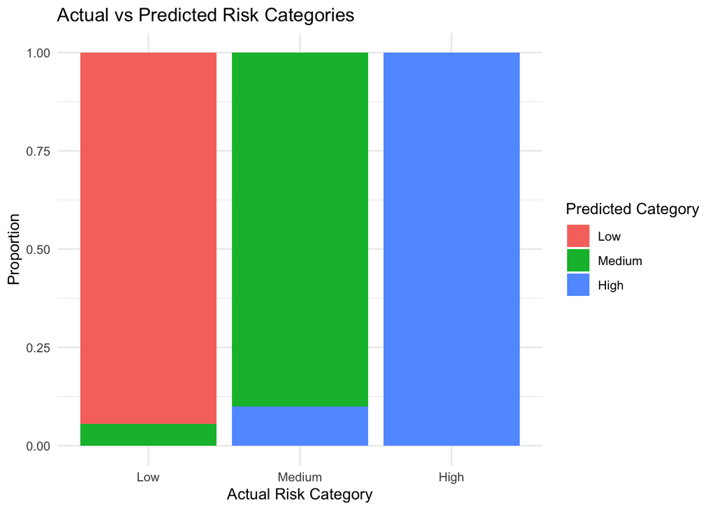

```r
# Generate predictions for the entire scaled_data
scaled_data <- scaled_data |>
  mutate(predicted_category = predict(multinom_model, newdata = scaled_data))

ggplot(scaled_data, aes(x = risk_category, fill = predicted_category)) +
  geom_bar(position = "fill") +
  labs(
    title = "Actual vs Predicted Risk Categories",
    x = "Actual Risk Category",
    y = "Proportion",
    fill = "Predicted Category"
  ) +
  theme_minimal()
```

#### ROC Curves for Multinomial Logistic Regression

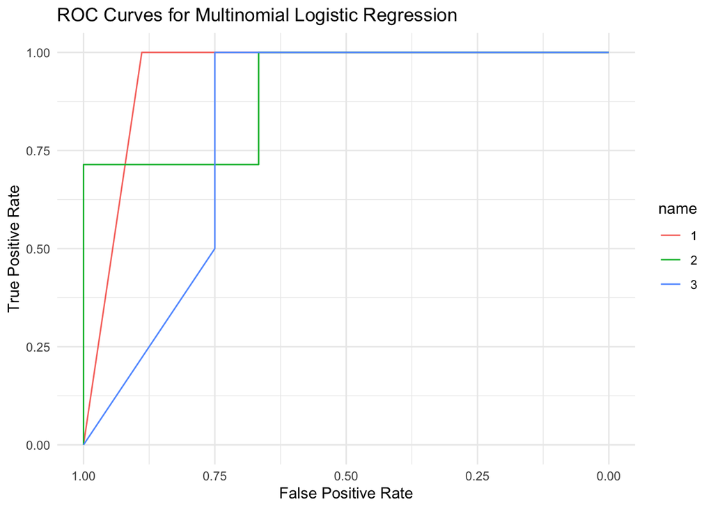

```r
# Generate predicted probabilities for the test data
test_data <- test_data |>
  mutate(predicted_probs = predict(multinom_model, newdata = test_data, type = "probs"))

library(tidyr)
library(pROC)

# Reshape predicted probabilities into long format
roc_data <- test_data |>
  mutate(
    Low = predicted_probs[, "Low"],
    Medium = predicted_probs[, "Medium"],
    High = predicted_probs[, "High"]
  ) |>
  pivot_longer(
    cols = c(Low, Medium, High),
    names_to = "class",
    values_to = "probability"
  ) |>
  mutate(
    true_label = ifelse(risk_category == class, 1, 0)  # Create binary labels
  )
# Plot ROC curve for each class
roc_list <- roc_data |>
  group_by(class) |>
  summarise(
    roc_curve = list(roc(response = true_label, predictor = probability))
  )

# Plot the ROC curves
library(ggplot2)
ggroc(map(roc_list$roc_curve, as.list)) +
  labs(
    title = "ROC Curves for Multinomial Logistic Regression",
    x = "False Positive Rate",
    y = "True Positive Rate"
  ) +
  theme_minimal()
```

## Text Analysis of the Mass Shootings

### Word Frequency Analysis

Identify the most common words or phrases in the descriptions.

- Tokenize the text into words.
- Remove stopwords (e.g., “and,” “the”) and punctuation.
- Count word frequencies.

```r
library(tidytext)
library(dplyr)

# Tokenize and count word frequencies
word_counts <- mass_shootings |>
  unnest_tokens(word, Description) |>
  anti_join(stop_words, by = "word") |>  # Remove stopwords
  count(word, sort = TRUE)

# View top words
head(word_counts, 20)
```

```
##            word    n
## 1        people 2067
## 2      shooting 1623
## 3        killed 1600
## 4       injured 1587
## 5       wounded 1502
## 6          shot  959
## 7  neighborhood  526
## 8          fire  511
## 9         party  466
## 10       person  418
## 11       police  409
## 12      morning  372
## 13         home  326
## 14    including  310
## 15        drive  290
## 16      fatally  258
## 17        woman  251
## 18       adults  231
## 19    escalated  231
## 20         park  230
```

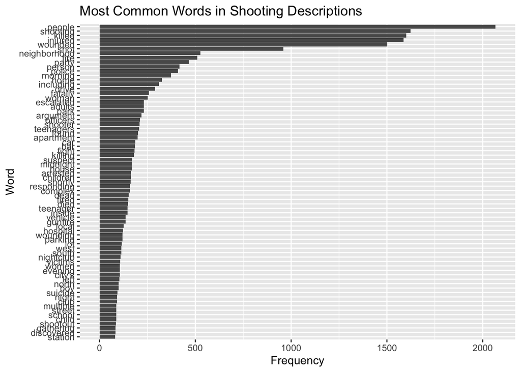

```r
library(ggplot2)

word_counts |>
  filter(n > 80) |>  # Filter for frequently occurring words
  ggplot(aes(x = reorder(word, n), y = n)) +
  geom_col() +
  coord_flip() +
  labs(title = "Most Common Words in Shooting Descriptions",
       x = "Word",
       y = "Frequency")
```

### Sentiment Analysis

Measure the overall sentiment (positive/negative/neutral) of the descriptions.

- Use sentiment lexicons (e.g., Bing, NRC).
- Assign sentiment scores to words in the descriptions.
- Aggregate scores for each description.

```r
library(tidyr)

# Perform sentiment analysis
sentiment_analysis <- mass_shootings |>
  unnest_tokens(word, Description) |>
  inner_join(get_sentiments("bing"), by = "word") |>
  count(sentiment) |>
  mutate(percentage = n / sum(n) * 100)

# View results
print(sentiment_analysis)
```

```
##   sentiment    n percentage
## 1  negative 3574  93.413487
## 2  positive  252   6.586513
```

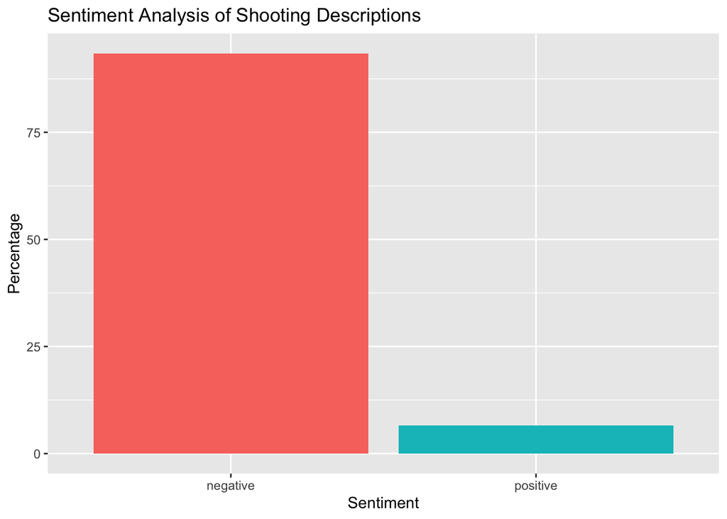

```r
# Plot sentiment distribution
sentiment_analysis |>
  ggplot(aes(x = sentiment, y = percentage, fill = sentiment)) +
  geom_col(show.legend = FALSE) +
  labs(title = "Sentiment Analysis of Shooting Descriptions",
       x = "Sentiment",
       y = "Percentage")
```

### Topic Modeling (LDA)

Identify underlying topics/themes in the descriptions. - Convert text into a document-term matrix. - Apply LDA to find clusters of words (topics).

```r
library(topicmodels)
library(tidytext)

# Create document-term matrix
dtm <- mass_shootings |>
  unnest_tokens(word, Description) |>
  anti_join(stop_words, by = "word") |>
  count(id = row_number(), word) |>
  cast_dtm(id, word, n)

# Apply LDA
lda_model <- LDA(dtm, k = 3, control = list(seed = 123))

# Extract topics
topics <- tidy(lda_model, matrix = "beta")

# View top terms per topic
top_terms <- topics |>
  group_by(topic) |>
  slice_max(beta, n = 10) |>
  ungroup()

top_terms
```

```
## # A tibble: 30 × 3
##    topic term           beta
##    <int> <chr>         <dbl>
##  1     1 shooting     0.0686
##  2     1 wounded      0.0494
##  3     1 shot         0.0332
##  4     1 party        0.0281
##  5     1 killed       0.0272
##  6     1 neighborhood 0.0233
##  7     1 people       0.0232
##  8     1 fatally      0.0156
##  9     1 fire         0.0152
## 10     1 escalated    0.0146
## # ℹ 20 more rows
```

#### Visualization:

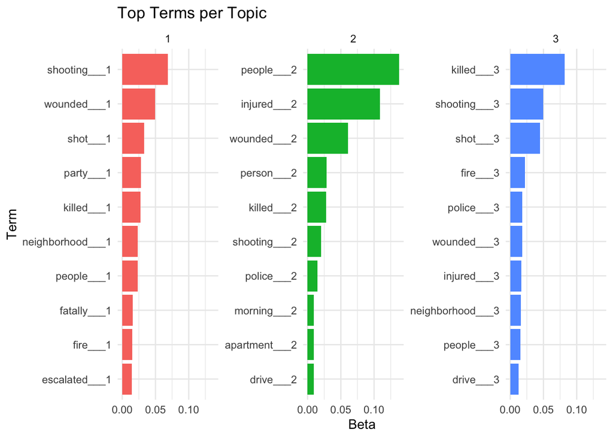

```r
top_terms |>
  mutate(term = reorder_within(term, beta, topic)) |>
  ggplot(aes(x = term, y = beta, fill = factor(topic))) +
  geom_col(show.legend = FALSE) +
  coord_flip() +
  facet_wrap(~ topic, scales = "free_y") +
  labs(title = "Top Terms per Topic",
       x = "Term",
       y = "Beta") +
  theme_minimal()
```

### Word Cloud

Create a visual representation of the most frequent words.

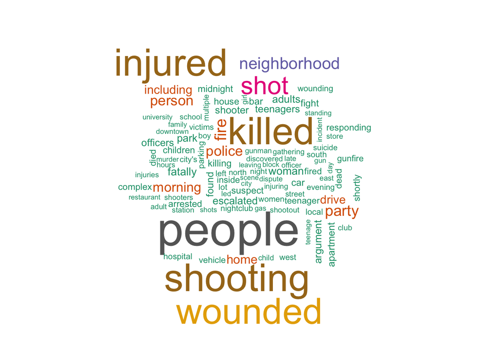

```r
library(wordcloud)

# Generate word cloud
wordcloud(words = word_counts$word,
          freq = word_counts$n,
          max.words = 100,
          colors = brewer.pal(8, "Dark2"))
```